# Literate Programming with Quarto

From data analysis to reproducible publications

Tiago José Camelo Moura

Data Analysis for Decision-Making · Prof. Dr. Stephan Huber · Hochschule Fresenius Köln · Winter term 2026/27 · Email: moura.tiago@stud.hs-fresenius.de · Student ID: 401518481

November 18, 2026

## The question behind the tools

**How can a reader trace a business conclusion back to the data and code that produced it?**

Literate programming connects the explanation, instructions, and computed outputs in one readable source.

## Why reproducibility matters

A result is easier to check when the data, transformations, code, software context, and interpretation are documented together.

- Copied results can become stale after code changes.
- Undocumented cleaning decisions are hard to audit.
- Reproduction requires access to the inputs and a sufficiently specified workflow.

A rendered report alone is not the whole research record (Gandrud, 2020; Peng, 2009).

## Literate programming: the core idea

Donald Knuth described programming as a form of writing for human readers as well as computers (Knuth, 1984).

**In a data report:** narrative explains decisions; code makes calculations explicit; output shows what that code produced.

The reader can move from question → method → result → interpretation without switching between disconnected files.

## What Quarto does

Quarto is an open-source publishing system. It reads a `.qmd` source and coordinates:

1. Markdown and document metadata
2. Execution of supported code cells (R commonly runs through knitr)
3. Conversion to HTML, PDF, or other publication formats (Quarto Development Team, n.d.)

**Quarto orchestrates the document; R performs R calculations.**

## Quarto and RStudio have different jobs

| Tool | Role in this workflow |
| --- | --- |
| R | Reads, transforms, summarises and plots data |
| Quarto | Renders `.qmd` sources into documents |
| RStudio | IDE: edit, run, preview, manage the project |

RStudio can call Quarto’s renderer, but project files can also be rendered from a terminal (Quarto Development Team, n.d.).

## Anatomy of a `.qmd`

```yaml
---
title: "Churn analysis"
format: html
bibliography: references.bib
csl: apa.csl
---
```

Below the YAML header, Markdown supplies prose and headings. Fenced R chunks contain executable code.

YAML controls **document-level choices**. Chunk options control **what an individual cell shows or executes**.

## Markdown and executable chunks

Markdown makes structure visible: `##` starts a section, `**text**` is bold, and backticks mark code.

```r
churn_data <- readr::read_csv("data/customer_churn_simulated.csv",
                              show_col_types = FALSE)
nrow(churn_data)                  # customers in the file
```

```
[1] 600
```

```r
mean(churn_data$churn == "Yes")   # overall churn rate
```

```
[1] 0.1566667
```

`#|` lines are cell options. `echo` controls code visibility; `eval: false` skips execution; `include: false` runs a cell but hides both code and result. These choices affect display, not analytical validity.

## Rendering: from source to publication

**Edit → execute → convert → inspect**

- In RStudio, use **Render** for the current document.
- From the project folder: `quarto render Tiago_Presentation.qmd`.
- Inspect the generated file; a successful build does not guarantee good layout or valid interpretation.

PDF output needs a working LaTeX engine; this project uses XeLaTeX.

## Citations and APA 7

A BibTeX database stores bibliographic metadata; CSL applies a citation style. Quarto/Pandoc resolves citation keys and builds a reference list.

- YAML: `bibliography: references.bib` and `csl: apa.csl`
- In text: `[@knuth1984]` or `@knuth1984`
- The reference list is generated from cited keys (Quarto Development Team, n.d.)

CSL controls formatting; it cannot verify that a source is real or relevant.

## Reproducible project structure

```
project/
  _quarto.yml
  Tiago_Presentation.qmd
  Handout_Quarto.qmd
  references.bib  apa.csl
  data/       # CSV + generator script
  analysis/   # worked churn analysis
  exercise/   # class exercise
```

Use relative paths, record data provenance and cleaning choices, keep a generator for simulated data, and state package requirements. Version control tracks source changes; it does not package every dependency automatically (Gandrud, 2020).

## Business question: customer churn and revenue risk

A telecom team wants to know which customer groups show more cancellations and where retention outreach may be worth testing.

- How does churn vary across contract type and tenure?
- How much recurring monthly revenue is associated with customers who leave?
- Which active segments have higher observed churn?

The project dataset is **simulated**, not company evidence.

## The data-to-decision workflow

1. Import the CSV and inspect rows, columns, types, and missingness.
2. Clean categories and fill missing monthly charges with the median within contract type; record the count.
3. Create tenure bands and a binary churn flag.
4. Summarize rates and revenue by contract and tenure.
5. Visualize segment rates and monthly revenue exposure.

Each step is executable and explained in `analysis/churn_analysis.qmd`.

## A readable analysis chunk

```r
customers |>
  group_by(contract) |>
  summarise(
    customers = n(),
    churn_rate = mean(churn == "Yes"),
    churned_mrr = sum(monthly_charge[churn == "Yes"]),
    .groups = "drop"
  )
```

The rate is the share of rows in each contract group marked as churned. `churned_mrr` is their monthly charge total at cancellation, **not a forecast of annual loss**.

## Visualize patterns, then interpret carefully

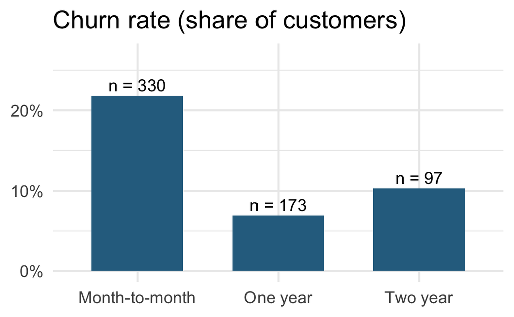

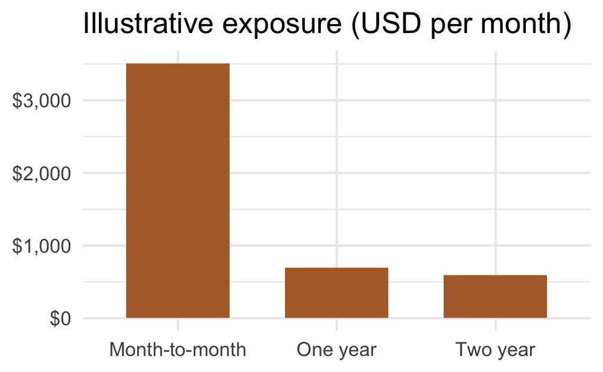

**Exposure** = active segment MRR × observed churn rate: a scenario for ranking priorities, not a calibrated forecast.

## Result snapshot from the simulated run

Calculated during rendering, after the contract-specific median imputation (fixed-seed synthetic sample).

| Contract | Customers | Churned | Churn rate | Observed churned MRR |
| --- | --- | --- | --- | --- |
| Month-to-month | 330 | 72 | 21.8% | USD 4,712 |
| One year | 173 | 12 | 6.9% | USD 815 |
| Two year | 97 | 10 | 10.3% | USD 587 |

## What the results can and cannot say

**Can say:** in this generated sample, churn rates and revenue exposure differ across recorded groups.

**Cannot say:** contract type or support history caused cancellation, or that an offer will prevent it.

Selection, measurement, omitted variables, and simulation rules limit generalization. Validate on real data and test interventions (Huber, 2025).

## Takeaways and class exercise

- Literate programming joins explanation, code, and computed output.
- Quarto renders; R computes; RStudio supports the workflow.
- Reproducibility needs documented data, decisions, software, and inspection.
- In the exercise, compare churn by contract and explain one limitation.

## References

Gandrud, C. (2020). *Reproducible research with R and RStudio* (3rd ed.). Chapman & Hall/CRC. https://doi.org/10.1201/9780429031854

Huber, S. (2025). *Data analysis for decision-making: Lecture notes*. https://hubchev.github.io/dadm/

Knuth, D. E. (1984). Literate programming. *The Computer Journal*, *27*(2), 97–111. https://doi.org/10.1093/comjnl/27.2.97

Peng, R. D. (2009). Reproducible research and Biostatistics. *Biostatistics*, *10*(3), 405–408. https://doi.org/10.1093/biostatistics/kxp014

## Use of AI tools

Generative AI tools (OpenAI ChatGPT/Codex, Anthropic Claude) were used as aids for drafting, coding and checking. Their use, my verification of all content, and my responsibility for the work are set out in the signed affidavit at the end of the handout.